# EDA_GRP 10 updated

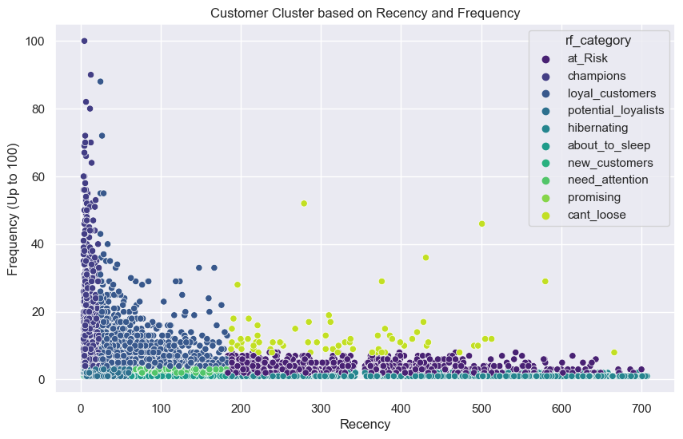

```python
#plotting a scatter plot to understand the relationship between recency and frequency across differnet customer segments
# Filtering the dataset to include only those with frequency up to 100
rfm_filtered = rfm[rfm['frequency'] <= 100]

# Plotting a scatter plot to understand the relationship between recency and frequency across different customer segments
plt.figure(figsize=(10, 6))
sns.scatterplot(x='recency', y='frequency', hue='rf_category', data=rfm_filtered, palette='viridis')
plt.title('Customer Cluster based on Recency and Frequency')
plt.xlabel('Recency')
plt.ylabel('Frequency (Up to 100)')
plt.show()
```

Observations and findings:

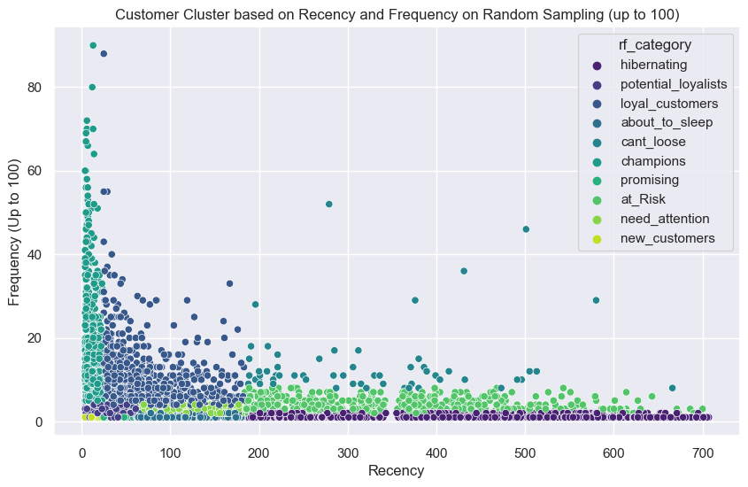

```python
#plotting a scatter plot to understand the Customer Cluster based on Recency and Frequency on Random Sampling (upto 400)
# Randomly sample 5000 rows from the dataset
rfm_sample = rfm.sample(n=5000, random_state=1000)

# Filter the sampled data to include only those with frequency up to 100
rfm_sample_filtered = rfm_sample[rfm_sample['frequency'] <= 100]

# Plotting a scatter plot to understand the relationship between recency and frequency across different customer segments
plt.figure(figsize=(10, 6))
sns.scatterplot(x='recency', y='frequency', hue='rf_category', data=rfm_sample_filtered, palette='viridis')
plt.title('Customer Cluster based on Recency and Frequency on Random Sampling (up to 100)')
plt.xlabel('Recency')
plt.ylabel('Frequency (Up to 100)')
plt.show()
```

Observations and findings:

1. The random sampling provides a more focused view of customer segments
2. The "champions" category stands out with high frequency and low recency, reinforcing their importance to the business
3. "Hibernating" and "about to sleep" customers are visible with higher recency values, indicating a need for reactivation campaigns
4. The spread of "potential loyalists" is clearer, showing a path for customer development from "new customers" to "loyal customers"

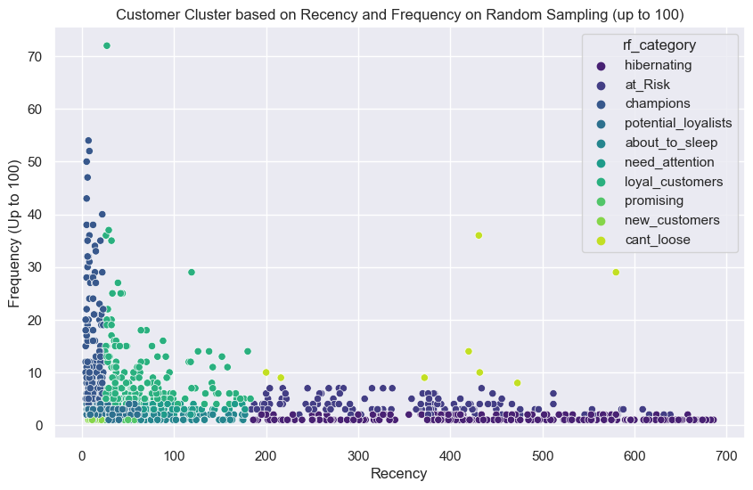

```python
#plotting a scatter plot to understand the Customer Cluster based on Recency and Frequency on Random Sampling (upto 200)
# Randomly sample 1000 rows from the dataset
rfm_sample = rfm.sample(n=1000, random_state=100)

# Filter the sampled data to include only those with frequency up to 100
rfm_sample_filtered = rfm_sample[rfm_sample['frequency'] <= 100]

# Plotting a scatter plot to understand the Customer Cluster based on Recency and Frequency on Random Sampling (up to 100)
plt.figure(figsize=(10, 6))
sns.scatterplot(x='recency', y='frequency', hue='rf_category', data=rfm_sample_filtered, palette='viridis')
plt.title('Customer Cluster based on Recency and Frequency on Random Sampling (up to 100)')
plt.xlabel('Recency')
plt.ylabel('Frequency (Up to 100)')
plt.show()
```

## 16. Hypothesis:

#### Null Hypothesis (H₀):

There is no significant difference in the average monetary value across different customer segments (rf_category).

#### Alternative Hypothesis (H₁):

There is a significant difference in the average monetary value across different customer segments (rf_category).

```python
# Grouping the data by rf_category
groups = [rfm[rfm['rf_category'] == category]['monetary'] for category in rfm['rf_category'].unique()]

# Conducting ANOVA
f_statistic, p_value = stats.f_oneway(*groups)

print(f"F-statistic: {f_statistic}")
print(f"P-value: {p_value}")

# Interpreting the results
if p_value < 0.05:
    print("Reject the null hypothesis: Significant difference in average monetary value between customer segments.")
else:
    print("Fail to reject the null hypothesis: No significant difference in average monetary value between customer segments.")
```

```
F-statistic: 7.620268363851451
P-value: 3.397577779364622e-11
Reject the null hypothesis: Significant difference in average monetary value between customer segments.
```

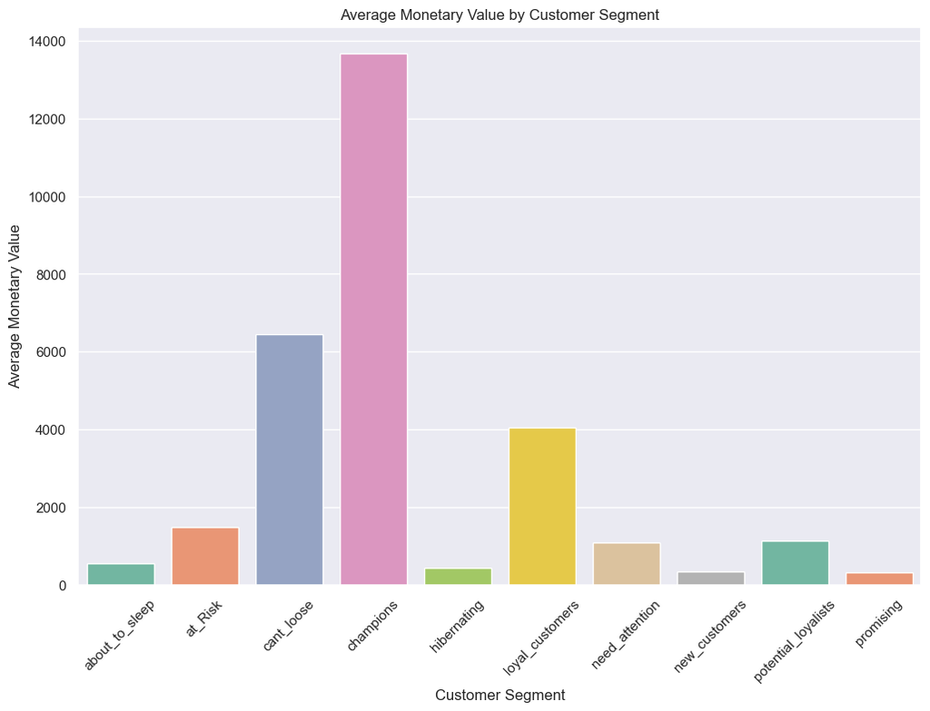

```python
# Calculate the average monetary value for each customer segment
avg_monetary_by_segment = rfm.groupby('rf_category')['monetary'].mean().reset_index()

# Set the figure size for the plot
plt.figure(figsize=(12, 8))

# Create a bar plot for average monetary value across different customer segments
sns.barplot(x='rf_category', y='monetary', data=avg_monetary_by_segment, palette='Set2')

# Set the title and labels
plt.title('Average Monetary Value by Customer Segment')
plt.xlabel('Customer Segment')
plt.ylabel('Average Monetary Value')

# Rotate the x-axis labels for better readability if needed
plt.xticks(rotation=45)

# Show the plot
plt.show()
```

## 17. Prediction

#### Predict Customer Future Spending

```python
# Create a dummy target variable for the modelling prediction
rfm['future_spending'] = np.random.rand(len(rfm))* 3000
rfm
```

| customer id | recency | frequency | monetary | recency_score | frequency_score | monetary_score | rf_score | rf_category | future_spending |
| --- | --- | --- | --- | --- | --- | --- | --- | --- | --- |
| 12346.0 | 329 | 7 | 77442.960000 | 2 | 4 | 5 | 24 | at_Risk | 2003.768749 |
| 12347.0 | 6 | 8 | 4921.530000 | 5 | 4 | 5 | 54 | champions | 651.389378 |
| 12348.0 | 79 | 5 | 2019.400000 | 3 | 4 | 4 | 34 | loyal_customers | 72.106051 |
| 12349.0 | 22 | 4 | 4428.690000 | 5 | 3 | 5 | 53 | potential_loyalists | 1211.552287 |
| 12350.0 | 314 | 1 | 334.400000 | 2 | 1 | 2 | 21 | hibernating | 2558.574435 |
| ... | ... | ... | ... | ... | ... | ... | ... | ... | ... |
| 18284.0 | 435 | 1 | 461.680000 | 1 | 2 | 2 | 12 | hibernating | 402.862960 |
| 18285.0 | 664 | 1 | 427.000000 | 1 | 2 | 2 | 12 | hibernating | 675.031818 |
| 18286.0 | 480 | 1 | 833.480000 | 1 | 2 | 3 | 12 | hibernating | 1016.080941 |
| 18287.0 | 46 | 7 | 4182.990000 | 4 | 4 | 5 | 44 | loyal_customers | 1490.280901 |
| Unavailable | 4 | 2939 | 2962849.810000 | 5 | 5 | 5 | 55 | champions | 1685.300229 |

5790 rows × 9 columns

```python
#creating the train test split for training and testing the model
from sklearn.model_selection import train_test_split
features = rfm[['recency', 'frequency', 'monetary']]

x = features
y = rfm['future_spending']

x_train, x_test, y_train, y_test = train_test_split(x, y, test_size=0.2, random_state=42)
```

#### Linear Regression Model

```python
from sklearn.linear_model import LinearRegression

lin_reg = LinearRegression()
lin_reg.fit(x_train, y_train)
```

```
LinearRegression()
```

#### Evaluation

```python
from sklearn.metrics import mean_squared_error, r2_score

pred = lin_reg.predict(x_test)

mse = mean_squared_error(y_test, pred)
r2 = r2_score(y_test, pred)

print(f"Mean Squared Error: {mse}")
print(f"R^2 Score: {r2}")
```

```
Mean Squared Error: 761549.1858153407
R^2 Score: -0.0017609382534187201
```

```python
#printing the results and storing it in a dataframe
results_df = pd.DataFrame({'Future Spending': y_test, 'Predicted Spending': pred})
results_df
```

| customer id | Future Spending | Predicted Spending |
| --- | --- | --- |
| 14281.000000 | 1546.145197 | 1491.705040 |
| 13933.000000 | 1030.210859 | 1481.745820 |
| 13421.000000 | 2908.148642 | 1478.309689 |
| 14927.000000 | 2823.000210 | 1491.351096 |
| 12505.000000 | 2596.337954 | 1492.078890 |
| ... | ... | ... |
| 18014.000000 | 2499.012610 | 1479.401914 |
| 18180.000000 | 440.359292 | 1476.990882 |
| 15509.000000 | 1694.045210 | 1490.752883 |
| 12552.000000 | 436.250244 | 1479.365219 |
| 12689.000000 | 958.304572 | 1479.372179 |

1158 rows × 2 columns

#### Decision Tree

```python
from sklearn.tree import DecisionTreeRegressor

dtr = DecisionTreeRegressor()
dtr.fit(x_train, y_train)
```

```
DecisionTreeRegressor()
```

#### Evaluation

```python
dtr_pred = dtr.predict(x_test)
mse = mean_squared_error(y_test, dtr_pred)
r2 = r2_score(y_test, dtr_pred)

print(f"Mean Squared Error: {mse}")
print(f"R^2 Score: {r2}")
```

```
Mean Squared Error: 1541874.0305467974
R^2 Score: -1.0282198501144086
```

```python
results_dt = pd.DataFrame({'Future Spending': y_test, 'Predicted Spending': dtr_pred})
results_dt
```

| customer id | Future Spending | Predicted Spending |
| --- | --- | --- |
| 14281.000000 | 1546.145197 | 1190.611057 |
| 13933.000000 | 1030.210859 | 2161.675178 |
| 13421.000000 | 2908.148642 | 472.950065 |
| 14927.000000 | 2823.000210 | 2577.513025 |
| 12505.000000 | 2596.337954 | 1913.009076 |
| ... | ... | ... |
| 18014.000000 | 2499.012610 | 899.266683 |
| 18180.000000 | 440.359292 | 171.676030 |
| 15509.000000 | 1694.045210 | 2003.274707 |
| 12552.000000 | 436.250244 | 2402.750019 |
| 12689.000000 | 958.304572 | 2267.522612 |

1158 rows × 2 columns

#### Future predicition

```python
new_customer_rfm = np.array([[10, 5, 300]])
pred_spending = lin_reg.predict(new_customer_rfm)

print(f"Predicted Future Spending: {pred_spending[0]}")
```

```
Predicted Future Spending: 1476.7470224694996
```

#### Lasso Regression Model or legacy Model

#### Train the model

```python
from sklearn.linear_model import Lasso
from sklearn.metrics import mean_squared_error, r2_score

# Initialize the Lasso Regression model with a regularization parameter alpha
lasso_reg = Lasso(alpha=0.1)

# Fit the model to the training data
lasso_reg.fit(x_train, y_train)
```

```
Lasso(alpha=0.1)
```

#### Make Prediction

```python
lasso_pred = lasso_reg.predict(x_test)
lasso_pred
```

```
array([1491.70373572, 1481.74378932, 1478.30969843, ..., 1490.75153373,
       1479.3630222 , 1479.36926061])
```

#### Evaluate model

```python
mse_lasso = mean_squared_error(y_test, lasso_pred)
r2_lasso = r2_score(y_test, lasso_pred)

print(f"Lasso Mean Squared Error: {mse_lasso}")
print(f"Lasso R^2 Score: {r2_lasso}")
```

```
Lasso Mean Squared Error: 761549.2384013617
Lasso R^2 Score: -0.0017610074263922915
```

```python
# Create a DataFrame to compare actual vs predicted spending
results_lasso = pd.DataFrame({'Future Spending': y_test, 'Predicted Spending': lasso_pred})
results_lasso.head()
```

| customer id | Future Spending | Predicted Spending |
| --- | --- | --- |
| 14281.0 | 1546.145197 | 1491.703736 |
| 13933.0 | 1030.210859 | 1481.743789 |
| 13421.0 | 2908.148642 | 1478.309698 |
| 14927.0 | 2823.000210 | 1491.349688 |
| 12505.0 | 2596.337954 | 1492.077001 |

```python
# Predict future spending for a new customer using Lasso Regression
pred_spending_lasso = lasso_reg.predict(new_customer_rfm)

print(f"Predicted Future Spending (Lasso): {pred_spending_lasso[0]}")
```

```
Predicted Future Spending (Lasso): 1476.7473896162899
```

## 17. ANALYSIS REPORT

#### ANALYSIS AND RECOMENDATIONS

#### Mean Values of Each Category:

| Category | Mean Recency (days) | Mean Frequency | Mean Monetary Value ($) |
| --- | --- | --- | --- |
| about_to_sleep | 105.87 | 1.35 | 547.68 |
| at_Risk | 359.80 | 3.85 | 1492.80 |
| cant_loose | 323.70 | 15.39 | 6438.34 |
| champions | 12.18 | 22.06 | 13670.68 |
| hibernating | 444.73 | 1.25 | 428.96 |
| loyal_customers | 68.65 | 9.49 | 4039.83 |
| need_attention | 112.62 | 3.08 | 1096.02 |
| new_customers | 14.44 | 1.00 | 355.10 |
| potential_loyalists | 28.58 | 2.55 | 1139.79 |
| promising | 41.77 | 1.00 | 325.80 |

## 18. Recommendations for Each Category:

1. **About_to_Sleep:**
   - **Action:** Re-engage customers before they churn by offering personalized discounts or special offers to entice them to make a purchase.
   - **Goal:** Increase frequency and customer retention by making these customers feel valued and reminding them of the brand.
2. **At_Risk:**
   - **Action:** Target these customers with win-back campaigns, such as loyalty rewards or personalized communication highlighting products they previously purchased.
   - **Goal:** Reduce recency and prevent these customers from becoming inactive, thereby improving their lifetime value.
3. **Cant_Loose:**
   - **Action:** Provide exclusive offers, loyalty programs, or high-touch customer service to reinforce their value and encourage continued high-frequency purchases.
   - **Goal:** Maintain and strengthen the relationship, ensuring they remain loyal and highly profitable.
4. **Champions:**
   - **Action:** Reward these customers with VIP treatment, early access to new products, or personalized experiences to acknowledge their loyalty.
   - **Goal:** Sustain their high frequency and monetary contributions, and leverage them as brand ambassadors.
5. **Hibernating:**
   - **Action:** Send targeted reactivation campaigns, such as reminders of previous purchases or new product launches, to bring them back.
   - **Goal:** Reignite their interest in the brand and encourage them to return to active purchasing.
6. **Loyal_Customers:**
   - **Action:** Strengthen loyalty by offering personalized recommendations, early access to sales, and loyalty rewards to keep them engaged.
   - **Goal:** Maintain their frequency and gradually increase their monetary contributions.
7. **Need_Attention:**
   - **Action:** Address potential issues by offering personalized customer service or resolving any complaints quickly, followed by an incentive to encourage repeat purchases.
   - **Goal:** Increase frequency and prevent them from slipping into the "at risk" or "hibernating" categories.
8. **New_Customers:**
   - **Action:** Welcome them with onboarding emails, small incentives for their next purchase, and introduce them to loyalty programs.
   - **Goal:** Increase their frequency and convert them into loyal customers.
9. **Potential_Loyalists:**
   - **Action:** Nurture these customers with targeted offers and personalized content to encourage more frequent purchases and higher spending.
   - **Goal:** Transition them into the "loyal customers" category by increasing both frequency and monetary value.
10. **Promising:**
    - **Action:** Encourage repeat purchases by offering discounts on their next purchase or showcasing best-selling products.
    - **Goal:** Move them into the "potential loyalists" category by increasing both frequency and recency.

#### Strategic Focus:

- **Enhanced Customer Retention:** Prioritize retaining "champions," "loyal customers," and "cant loose" segments by rewarding their loyalty.
- **Optimized Customer Acquisition:** Focus on converting "promising," "new customers," and "potential loyalists" into loyal customers with targeted engagement strategies.
- **Increased Profitability:** Balance efforts between acquiring new high-value customers and retaining existing ones to ensure sustainable growth.